# Results

Cecilia Sanchez

2026-05-11

[output not shown]

##### *Dataset summary*

Restricting the EHA research outputs catalog to only include peer-reviewed journal articles published from January 1, 2011 through December 31, 2022 resulted in a corpus of 451 articles. We identified 898 first and last authorships (FLA) associated with those articles, which were linked to 498 unique authors.

##### *Comparison of two approaches to classify author gender*

Using the pronouns-based approach, we classified 280 authors (56.2%) as gendered male, 181 (36.3%) as gendered female, and 1 (0.2%) as nonbinary. We were unable to find pronoun data for 36 authors (7.2%). Of the 462 authors for whom we were able to find pronouns, publicly available online information was the source for 323 (69.9%), while professional interactions were the source for the remaining 139 (30.1%). Using the name-based approach, we classified 265 authors (53.2%) as gendered male, 159 (31.9%) as gendered female, 56 (11.2%) as uncertain, and 18 (3.6%) as undetermined. Agreement between the two gender classification approaches was generally high (**Table S1**). However, there were 4 cases where an author was gendered female or nonbinary based on pronouns but gendered male based on name, and 3 cases where an author was gendered male based on pronouns but gendered female based on name.

##### *Gender composition of authors and authorships*

After combining the results of our two gender classification approaches, prioritizing gender based on pronouns in cases of disagreement, we ultimately classified 297 authors (59.6%) as gendered male, 186 (37.3%) as gendered female, 1 (0.2%) as nonbinary, and 14 (2.8%) as unknown gender. Of all FLA, 584 (65%) were by gendered male authors, 295 (32.9%) were by gendered female authors, 1 (0.1%) was by a nonbinary author, and 18 (2%) were by authors of unknown gender.

For both the first and last author positions, there were more authorships by gendered male authors than by gendered female authors (first-male: 29.3% of all FLA, first-female: 19.5%, last-male: 35.7%, last-female: 13.4%; **Fig. S1**). Nearly three-quarters of all authors (73.7%) had one authorship each (226 gendered male authors and 141 gendered female authors) (**Fig. 1**). There was only 1 gendered female author with ≥ 10 total FLA, while there were 10 gendered male authors with 10 - 44 total FLA each. Collectively, those 10 gendered male authors accounted for 187 (20.8%) of all FLA in the corpus (**Fig. 1**).

##### *Alignment of authorship geography and article geography*

We found that 280 articles (62.1% of all articles in the corpus) were geographically focused on one or more non-US countries (e.g. field or labwork was performed there, specialized knowledge of a country was required to perform the research). About two-thirds of the time (63.9%), either the first or last authorship geography matched the article geography. First authorship geography matched article geography 53.6% of the time, whereas last authorship geography matched article geography 47.1% of the time. Both first and last authorships matched the article geography 36.7% of the time.

##### *Network patterns in FLA*

Articles and authors represent two components of a bipartite graphs. Authors are linked by co-authorship on an article. Because we are interested in the connections between people, we re-project the bipartite graph such that the graph contains weighted edges between authors based on their co-authorships. Using the author graph, we examine the relationship between gender and centrality. Here we focus on two measures of centrality: betweenness and mean harmonic centrality.

Betweenness measures the number of shortest paths a node resides on. The shortest path is the walk between two nodes that requires traversing the least number of edges. A node with high betweenness is structurally important to the graph. In our analysis, authors are nodes, and authors with high betweenness likely represent people in positions of “power” - PI, resource control, etc - within the network.

Harmonic mean centrality measures the degree of a node and its neighbors up to certain distance. The higher the degree of a node and its neighbors, the higher the harmonic mean centrality – with the important caveat that the influence of neighbors decays with distance. This tells us about how well connected nodes and their neighbors are to the rest of the graph. Here, an author with high harmonic centrality is collaborating with many people who are also collaborating with many people.

#### Figure 1

Fig 1. Total first and last authorships associated with unique authors. Gendered female (n = 186) and gendered male (n = 297) authors are displayed in the top and bottom panels respectively. Authors classified as nonbinary (n = 1) or unknown (n = 14) are not displayed. Note that the y-axis is on a square-root scale.

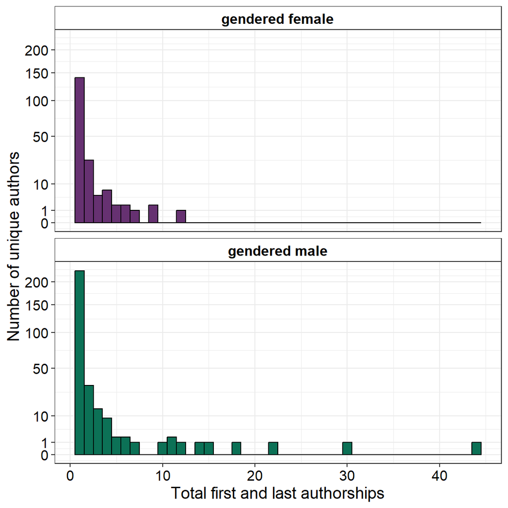

#### Figure 2

Fig 2. Percent of all first and last authorships (n = 898) separated by country income. Colors indicate author gender and shading indicates authorship position. A total of 43 countries were represented in first and last authorship affiliations (high-income: n = 19, upper-middle-income: n = 8, lower-middle-income: n = 13, low-income: n = 3).

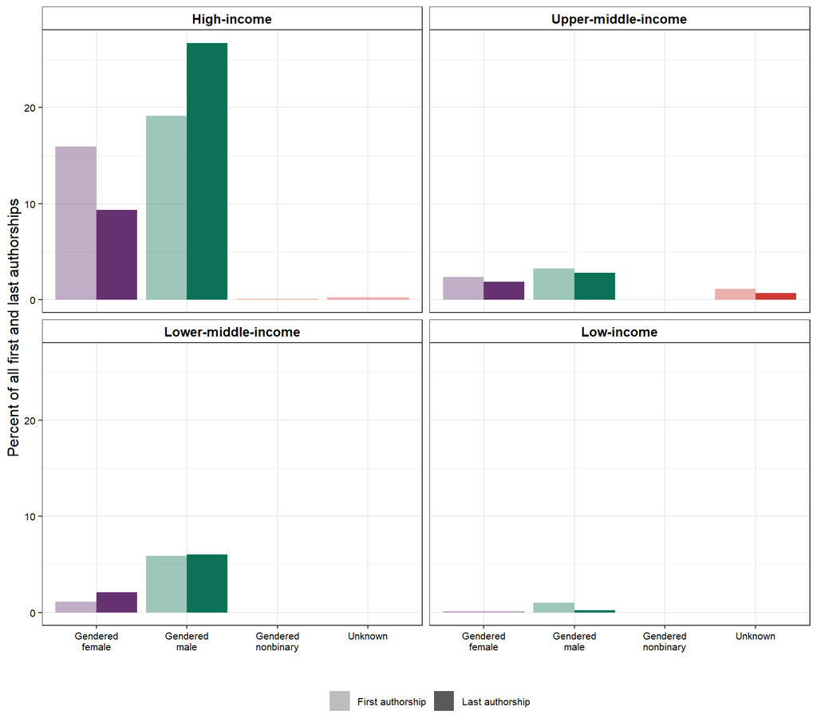

#### Figure 3

Fig 3. Observed and model-predicted gendered female authorship. (A) Observed percent of authorships by gendered female authors over time, separated by authorship position. (B) Model-predicted percent of authorships by gendered female authors, separated by authorship position and country income.

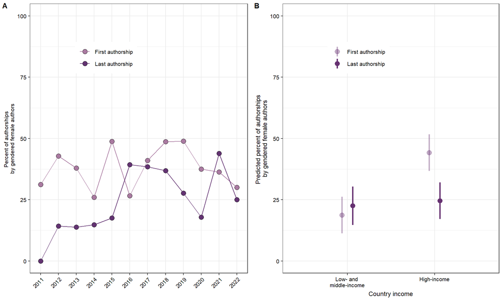

#### Figure 4

Fig 4. Depictions of the author network by two measures of centrality. In both panels, node (author) color indicates gender. (A) Network with node size representing betweenness centrality, which conveys information about the structural importance of an individual to the overall network. (B) Network with node size representing harmonic centrality, which conveys information about how connected an individual is to the rest of the graph.

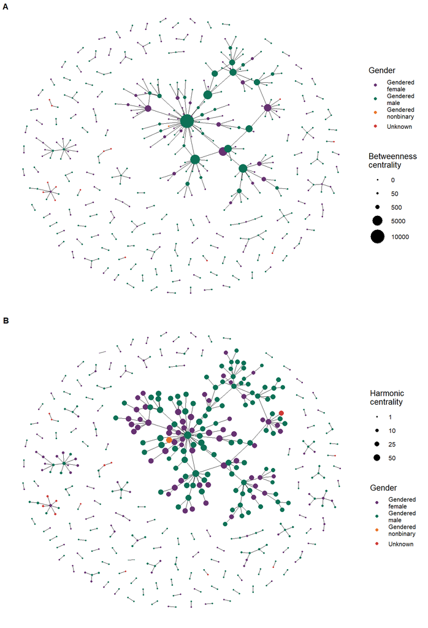

#### Figure S1

Fig S1. Percent of all first and last authorships (n = 898) separated by author gender and authorship position.

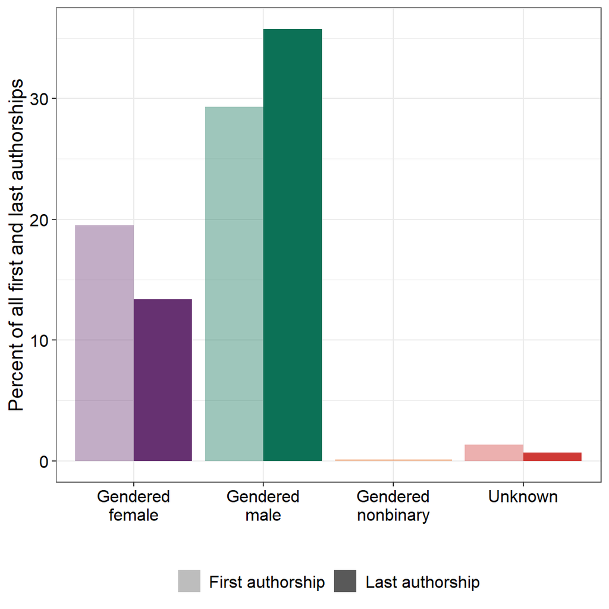

#### Figure S2

Fig S2. Number of first and last authorships (n = 898) separated by country affiliation. Points are colored according to country income. Note that the x-axis is on a log-10 scale.

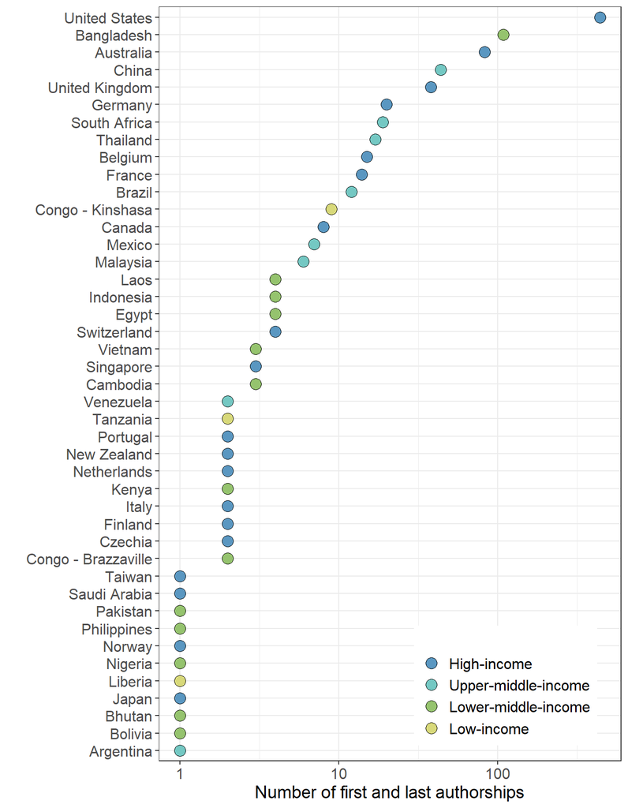

#### Figure S3

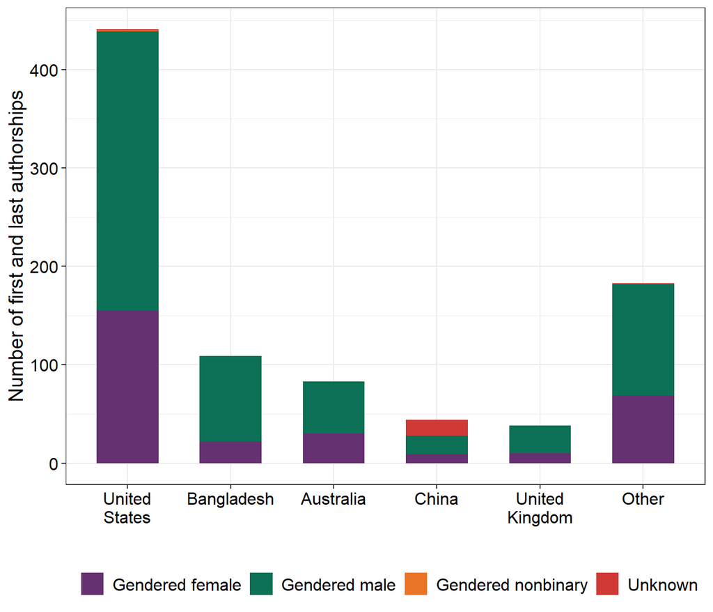

#### Figure S4

Fig S4. Percent of all first and last authorships (n = 898) separated by country income and authorship position.

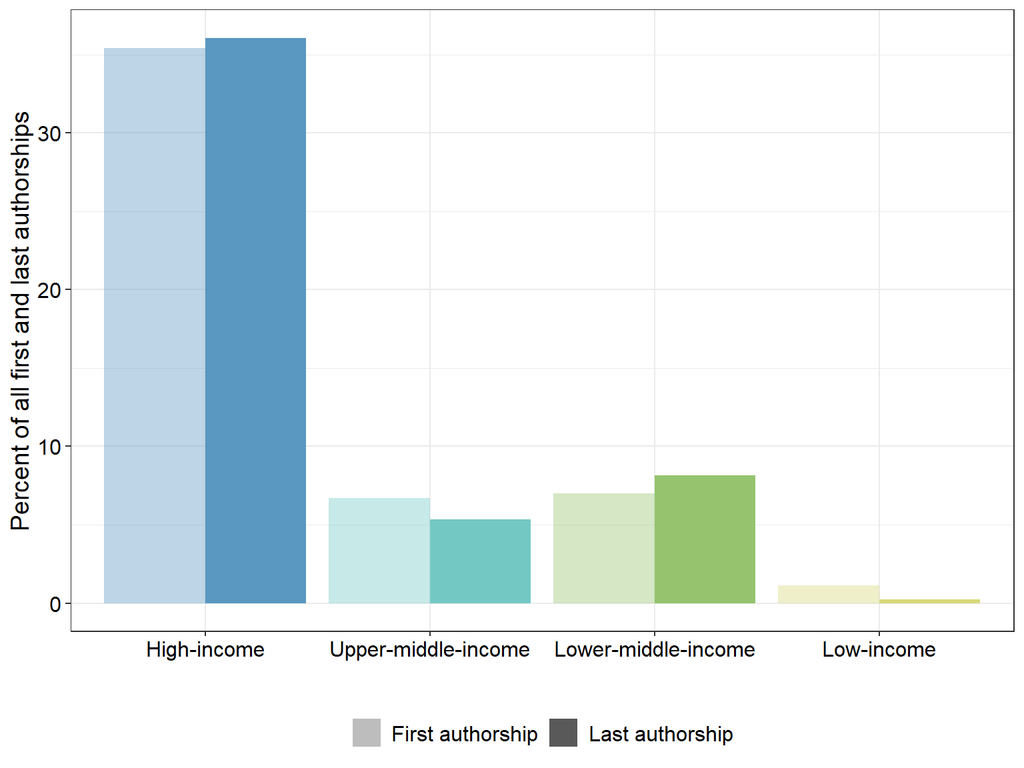

#### Table s1

Table S1. Comparison of a pronouns-based approach and a name-based approach to classify author genders. See Gender classification of authors in the main text for details of how authors were classified using each approach.

|  | gendered female | gendered male | uncertain | undetermined |
| --- | --- | --- | --- | --- |
| gendered female | 151 | 3 | 20 | 7 |
| gendered male | 3 | 244 | 24 | 9 |
| non-binary/gender non-conforming | 0 | 1 | 0 | 0 |
| undetermined | 5 | 17 | 12 | 2 |

#### Table s2

Table S2. Last authorships as a percentage of all first and last authorships (FLAs) for the most productive authors in the dataset (i.e. ≥ 10 FLAs).

```
## → reading _targets/meta/meta
```

| cleaned_name | gender_final | authorship_position | n | tot_FLA | perc_last_auth |
| --- | --- | --- | --- | --- | --- |
| 86db4004698005bd08ef7ba23f1e7a53 | gendered male | last | 39 | 44 | 88.6 |
| d01ed444567ef4609052367dc4e91c56 | gendered male | last | 13 | 30 | 43.3 |
| 327cf5887945fb35912989b6b9a63686 | gendered male | last | 15 | 22 | 68.2 |
| 9a74a9d818d316d8884d6cbb6f6dccf7 | gendered male | last | 14 | 18 | 77.8 |
| 70fd9e530aa10fed26ba6950248eb1cc | gendered male | last | 8 | 15 | 53.3 |
| 36c674377072650b92be91ce8a077728 | gendered male | last | 13 | 14 | 92.9 |
| 21887710a2816a61e60b51e6b644d738 | gendered female | last | 12 | 12 | 100.0 |
| fadf7bc6a81b666813f4b6509b28df5e | gendered male | last | 12 | 12 | 100.0 |
| 055d63312f9d33f5e619d2382788ade0 | gendered male | last | 2 | 11 | 18.2 |
| a5fd29b8bbda306045df1d92bee18e37 | gendered male | last | 8 | 11 | 72.7 |
| dccd0f81107e122ae9b33e9107219383 | gendered male | last | 7 | 10 | 70.0 |

#### Table s3

Table S3. Model coefficients for a linear model to examine effects of authorship position, country income, and year on the percent of authorships by gendered female authors. The “Year” variable was centered around 2011 to improve coefficient interpretability. P values < 0.05 are bolded.

```
## → reading _targets/meta/meta
```

```
##
## Call:
## lm(formula = perc_female ~ year_centered * authorship_position +
##     authorship_position * income_majority, data = model_dat)
##
## Residuals:
##     Min      1Q  Median      3Q     Max
## -20.306  -6.971  -2.042   6.828  38.888
##
## Coefficients:
##                                                    Estimate Std. Error t value
## (Intercept)                                         13.9675     5.5740   2.506
## year_centered                                        0.8499     0.7579   1.121
## authorship_positionLast                             -4.3468     8.3297  -0.522
## income_majorityHigh-income                          25.5050     5.2329   4.874
## year_centered:authorship_positionLast                1.4484     1.1063   1.309
## authorship_positionLast:income_majorityHigh-income -23.4512     7.4949  -3.129
##                                                    Pr(>|t|)
## (Intercept)                                         0.01628 *
## year_centered                                       0.26865
## authorship_positionLast                             0.60459
## income_majorityHigh-income                         1.68e-05 ***
## year_centered:authorship_positionLast               0.19774
## authorship_positionLast:income_majorityHigh-income  0.00323 **
## ---
## Signif. codes:  0 '***' 0.001 '**' 0.01 '*' 0.05 '.' 0.1 ' ' 1
##
## Residual standard error: 12.82 on 41 degrees of freedom
##   (1 observation deleted due to missingness)
## Multiple R-squared:  0.4758, Adjusted R-squared:  0.4118
## F-statistic: 7.442 on 5 and 41 DF,  p-value: 4.805e-05
```

#### Table s4

Table S4. Matches between authorship geography (i.e. country affiliation) and article geography (i.e. the geographic focus of a study, excluding the United States). A “match” occurred when the authorship geography was the same as any of the countries contained in the article geography. Values are provided for the whole timespan of the data (2011-2022) as well as broken down into two time periods (2011-2016 and 2017-2022) to explore potential changes in authorship over time. Denominator sizes are sometimes different because not all articles had a last authorship (i.e. sole-authored articles, which were counted as first authorships).

| time_period | first_authorship_match | last_authorship_match | either_match | both_match |
| --- | --- | --- | --- | --- |
| 2011-2022 | 150/280 (53.6%) | 131/278 (47.1%) | 179/280 (63.9%) | 102/278 (36.7%) |
| 2011-2016 | 51/95 (53.7%) | 43/94 (45.7%) | 61/95 (64.2%) | 33/94 (35.1%) |
| 2017-2022 | 99/185 (53.5%) | 88/184 (47.8%) | 118/185 (63.8%) | 69/184 (37.5%) |

#### Table s5

**Table S5.** A summary of two measures of network centrality (betweenness centrality and harmonic centrality) calculated for authors separated by gender. HDCI = high density confidence interval.

| gender | group_size | median_btw | mean_btw | hdci_btw_low | hdci_btw_high | median_hc | mean_hc | hdci_hc_low | hdci_hc_high |
| --- | --- | --- | --- | --- | --- | --- | --- | --- | --- |
| gendered female | 186 | 0 | 64.84 | 0 | 190.6 | 1.83 | 11.25 | 0.65 | 43.12 |
| gendered male | 297 | 0 | 129.21 | 0 | 317.0 | 2.00 | 11.51 | 0.83 | 43.12 |
| nonbinary | 1 | 0 | 0.00 | 0 | 0.0 | 43.12 | 43.12 | 43.12 | 43.12 |
| unknown | 14 | 0 | 0.21 | 0 | 2.0 | 1.67 | 3.95 | 1.00 | 28.51 |